# pca

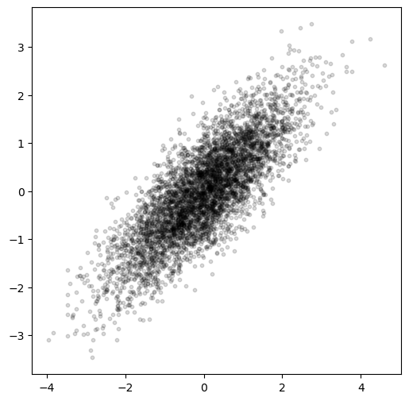

N = 10_000, not bad. And it's got a pretty tight distribution. We can see that the distribution points in one main direction up and to the right. What direction is this data trending in? We can find the answer with PCA.

Now we have something that captures the directions that this data is stretchiest and squishiest in. But notice that the our arrows don't seem to accurately capture *how* stretchy and squishy our data is.

```
tensor(1.)
```

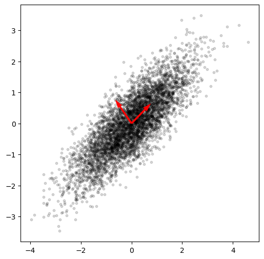

We can refine things by scaling these arrows by our eigenvalues.

We can see that the length of our arrows corresponds to the degree of stretch and squish of our data

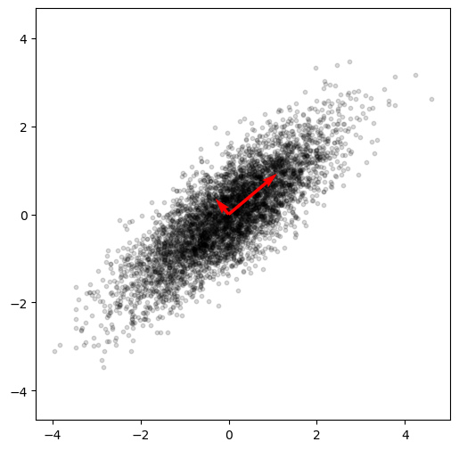

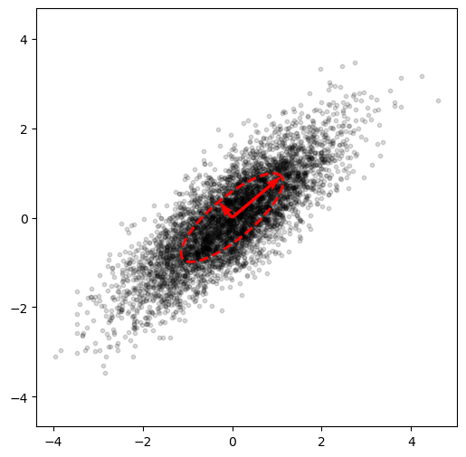

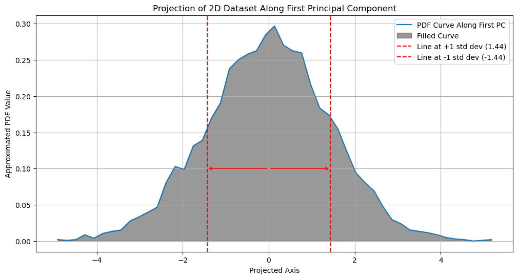

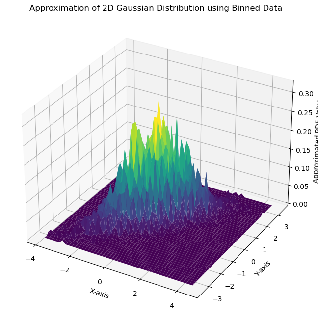

Now that we've seen what principal component analysis is, we can discuss how it works.\ In a phrase, the principal components of a dataset are the eigenvectors of the covariance matrix of that dataset. Those eigenvectors correspond to the directions of highest variance of the dataset, and the eigenvalues correspond to the variance across the dimensions that the eigenvectors point in. Visually, I suggest walking back through the images with this extra context.

```
torch.Size([2, 2])
```